# 3D Geoplotting using Uber Movement Data

In this notebook, we will look at how we can build 3D Plots in R. Let us make this plot a 3D plot. Using Rayshader, building 3D plots are easy. The depth of the plot is based on the fill variable

```r
library(ggplot2)
library(ggmap)
#devtools::install_github("tylermorganwall/rayshader")  #Use this to install Rayshader. The package from CRAN gives error when running plot_gg

#chhattisgarh,Jammu and kashmir, Pondicherry -> Pudhucherry, uttarakhand to Uttanchal, Odisha to Orissa

library(Hmisc)
library(rayshader)
library(rgdal)
library(RColorBrewer)
library(data.table)
library(dplyr)
library(sf)
library(viridis)
#library(RJSONIO)
library(jsonlite)
```

### A Basic Introduction

Before we go to Maps, let us look at how we can make simple plots into 3D in R

```r
gg = ggplot(diamonds, aes(x, depth)) +
  stat_density_2d(aes(fill = stat(nlevel)),
                  geom = "polygon",
                  n = 100,bins = 10,contour = TRUE) +
  facet_wrap(clarity~.) +
  scale_fill_viridis_c(option = "A")
plot_gg(gg,multicore=TRUE,width=5,height=5,scale=250)
```

[output not shown]

Look at Death Probability vs Age and Year for USA

```r
#Data from Social Security administration
death = read.csv("https://www.tylermw.com/data/death.csv", skip = 1)
meltdeath = reshape2::melt(death, id.vars = "Year")

meltdeath$age = as.numeric(meltdeath$variable)
deathgg = ggplot(meltdeath) +
  geom_raster(aes(x=Year,y=age,fill=value)) +
  scale_x_continuous("Year",expand=c(0,0),breaks=seq(1900,2010,10)) +
  scale_y_continuous("Age",expand=c(0,0),breaks=seq(0,100,10),limits=c(0,100)) +
  scale_fill_viridis("Death\nProbability\nPer Year",trans = "log10",breaks=c(1,0.1,0.01,0.001,0.0001), labels = c("1","1/10","1/100","1/1000","1/10000")) +
  ggtitle("Death Probability vs Age and Year for the USA") +
  labs(caption = "Data Source: US Dept. of Social Security")

plot_gg(deathgg, multicore=TRUE,height=5,width=6,scale=500)
```

[output not shown]

Let us make this plot a 3D plot. It is very simple usinf RayShader Library - pass the ggplot object to plot_gg() function.

To download the data from https://movement.uber.com/ - We will look at aggregate data of Travel Times by Hour of Day for all days for Q1 2019

```r
setwd("/Users/aiswarya/DataScienceArena/BRUG Workshop/")

travel_time=read.csv("data/bangalore-wards-2019-1-All-HourlyAggregate.csv")

print("Dimensions of the Data ")
```

```
[1] "Dimensions of the Data "
```

```r
print(dim(travel_time))
```

```
[1] 836029      7
```

```r
print("Columns in the Data ")
```

```
[1] "Columns in the Data "
```

```r
print(colnames(travel_time))
```

```
[1] "sourceid"                                 "dstid"
[3] "hod"                                      "mean_travel_time"
[5] "standard_deviation_travel_time"           "geometric_mean_travel_time"
[7] "geometric_standard_deviation_travel_time"
```

The data has columns sourceid and dstid, which represents the source and destination wards. hod is the hour of the day along with the means and standard deviation of the travel time. Let us understand the data a little better

```r
unique_wards=unique(travel_time$sourceid)
print("Number of Unique Source Wards ")
```

```
[1] "Number of Unique Source Wards "
```

```r
print(length(unique_wards))
```

```
[1] 198
```

```r
unique_wards_dst=unique(travel_time$dstid)
print("Number of Unique Destination Wards ")
```

```
[1] "Number of Unique Destination Wards "
```

```r
print(length(unique_wards_dst))
```

```
[1] 198
```

We will look at what is the Average Travel Time from a particular Ward

```r
travel_time=data.table(travel_time)

src_avg_travel_time=travel_time %>%group_by(sourceid) %>%summarize(Avg_Travel_Time_From_Wards=mean(mean_travel_time,na.rm=TRUE))
```

We need to map the source and destination id to zone. The zone data can also be downloaded from uber movement

```r
zone_json=fromJSON("data/bangalore_wards.json")
ward_data=zone_json$features
ward_data=ward_data$properties
ward_data$MOVEMENT_ID<-as.integer(ward_data$MOVEMENT_ID)

travel_time=merge(travel_time,ward_data,by.x='sourceid',by.y='MOVEMENT_ID',all.x=T)
dim(travel_time)
```

```
[1] 836029     10
```

```r
travel_time=travel_time %>%
  rename(
     Source_WARD_NO=WARD_NO,
    Source_WARD_NAME=WARD_NAME ,
    Source_DISPLAY_NAME=DISPLAY_NAME
    )


travel_time=merge(travel_time,ward_data,by.x='dstid',by.y='MOVEMENT_ID',all.x=T)


travel_time=travel_time %>%
  rename(
     DST_WARD_NO=WARD_NO,
    DST_WARD_NAME=WARD_NAME ,
    DST_DISPLAY_NAME=DISPLAY_NAME
    )

src_avg_travel_time=merge(src_avg_travel_time,ward_data,by.x='sourceid',by.y='MOVEMENT_ID',all.x=T)
```

Let us look at how we can plot this data to understand traffic patterns in Bangalore. For this we need to download the Shape file of Bangalore. To download the shape files from this link: https://github.com/openbangalore/bangalore/tree/master/bangalore/GIS

```r
blr = st_read("data/bbmpwards/bbmpwards.shp", quiet = TRUE)

source_blr=merge(blr,src_avg_travel_time,by='WARD_NO',all.x=T)
```

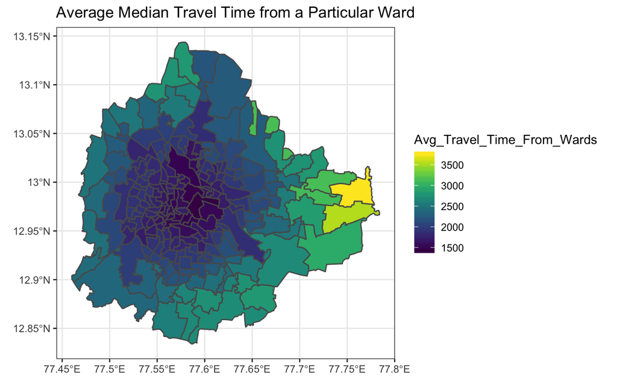

```r
gg_src_blr = ggplot(source_blr) +
  geom_sf(aes(fill = Avg_Travel_Time_From_Wards)) +
  scale_fill_viridis("Avg_Travel_Time_From_Wards") +
  ggtitle("Average Median Travel Time from a Particular Ward") +
  theme_bw()

gg_src_blr
```